# **✨ Kidney Stone Prediction ✨**

### Author: Kumod Sharma .📄🖋️

[figure not shown]

# **🎬 Introduction 🎬**

### 📝 Project Objective:

1. The primary objective of this project is to conduct a comprehensive analysis of kidney stone prediction, focusing on understanding the underlying factors that contribute to kidney stone formation and predicting the likelihood of kidney stone occurrence in patients.  
2. The project aims to analyze various urinary characteristics of patients in order to uncover patterns and insights related to kidney stone formation. By examining features such as urine gravity, pH, osmolality, conductivity, urea, and calcium levels, the goal is to gain a deeper understanding of the physiological factors associated with kidney stone risk.

# **📝 Project Contents 📝**

### 📊 Table of Contents:

1. **📚 Importing Libraries.**
1. **⏳ Loading Datasets.**
1. **🧠 Basic Understanding of Data.**
1. **📊 Exploratory Data Analysis (EDA)**
1. **💡 Feature Engineering.**
1. **📈 Statistical Analysis - Feature Importance.**
1. **⚙️ Data Preprocessing.**
1. **🎯 Model Creation and Evaluation.**
1. **🎈 Conclusion.**

# **📚 Importing Libraries 📚**

```python
import numpy as np
import pandas as pd
import seaborn as sns
import matplotlib.pyplot as plt
import warnings
warnings.filterwarnings("ignore")
sns.set(style="darkgrid",font_scale=1.5)

from scipy import stats

from sklearn.tree import DecisionTreeClassifier
from sklearn.ensemble import RandomForestClassifier


from sklearn.model_selection import train_test_split, GridSearchCV
from sklearn.metrics import accuracy_score, precision_score, recall_score ,f1_score
from sklearn.metrics import confusion_matrix, roc_curve, roc_auc_score
```

# **⏳ Loading Datset ⏳**

```python
df = pd.read_csv("C:\\Users\\kumod sharma\\Desktop\\ML Datasets\\kidney-stone-dataset.csv",index_col=[0])
```

```python
df.head()
```

|  | gravity | ph | osmo | cond | urea | calc | target |
| --- | --- | --- | --- | --- | --- | --- | --- |
| 0 | 1.021 | 4.91 | 725 | 14.0 | 443 | 2.45 | 0 |
| 1 | 1.017 | 5.74 | 577 | 20.0 | 296 | 4.49 | 0 |
| 2 | 1.008 | 7.20 | 321 | 14.9 | 101 | 2.36 | 0 |
| 3 | 1.011 | 5.51 | 408 | 12.6 | 224 | 2.15 | 0 |
| 4 | 1.005 | 6.52 | 187 | 7.5 | 91 | 1.16 | 0 |

# **🧠 Basic Understanding of Data 🧠**

### 1. Checking the Dimensions of Dataset.

```python
print("Total number of records/rows present in the dataset is:",df.shape[0])
print("Total number of attributes/columns present in the dataset is:",df.shape[1])
```

```
Total number of records/rows present in the dataset is: 90
Total number of attributes/columns present in the dataset is: 7
```

### 2. Fetching the Attributes Names.

```python
df.columns
```

```
Index(['gravity', 'ph', 'osmo', 'cond', 'urea', 'calc', 'target'], dtype='object')
```

### 📊 Inference:

1. **Gravity:** It refers to **urine specific gravity,** which measures the concentration of dissolved substances in urine.
2. **pH:** pH measures the **acidity or alkalinity of urine.**
3. **Osmo (Osmolality):** Osmolality measures the **concentration of solutes (particles) in urine.**
4. **Cond (Conductivity):** It measures the **ability of urine to conduct electricity**, which is influenced by the concentration of ions in the urine.
5. **Urea:** Urea is a **waste product produced by the liver** as a result of protein metabolism.
6. **Calc (Calcium):** Calcium is an important **mineral that plays a role in bone health, muscle function, and nerve transmission.**
7. **Target:** This is likely your target variable, which represents the **presence or absence of kidney stones.**

### 3. Assigning More Suitable Column Names for better Analysis.

```python
df.rename(columns={"gravity":"Urine_Gravity","ph":"Urine_pH","osmo":"Osmolality","cond":"Conductivity","urea":"Urea",
                  "calc":"Calcium","target":"Target"},inplace=True)
```

### 4. Generating Basic Information of the data.

```python
df.info()
```

```
<class 'pandas.core.frame.DataFrame'>
Int64Index: 90 entries, 0 to 89
Data columns (total 7 columns):
 #   Column         Non-Null Count  Dtype
---  ------         --------------  -----
 0   Urine_Gravity  90 non-null     float64
 1   Urine_pH       90 non-null     float64
 2   Osmolality     90 non-null     int64
 3   Conductivity   90 non-null     float64
 4   Urea           90 non-null     int64
 5   Calcium        90 non-null     float64
 6   Target         90 non-null     int64
dtypes: float64(4), int64(3)
memory usage: 5.6 KB
```

### 📊 Inference:

* There is total **90 records** and **7 columns** availabe in the dataset. * **Out of 7 columns** all of them are **numerical columns.**

### 5. Computing Total No. of Missing Values.

```python
df.isnull().sum().to_frame().rename(columns={0:"Total No. of Missing Values"})
```

|  | Total No. of Missing Values |
| --- | --- |
| Urine_Gravity | 0 |
| Urine_pH | 0 |
| Osmolality | 0 |
| Conductivity | 0 |
| Urea | 0 |
| Calcium | 0 |
| Target | 0 |

### 📊 Inference:

- **None** of the columns is having **missing values.**
- So we **don't** have to perform **Data Imputation.**

### 6. Checking Duplicate Records.

```python
df.duplicated().any()
```

```
False
```

### 📊 Inference:

- There are **no duplicate records** present in the dataset.
- So we can say there is no **Data Lekage** in the dataset.

### 7. Performing Descriptive Statistical Analysis.

```python
df.describe().T
```

|  | count | mean | std | min | 25% | 50% | 75% | max |
| --- | --- | --- | --- | --- | --- | --- | --- | --- |
| Urine_Gravity | 90.0 | 1.017952 | 0.006780 | 1.005 | 1.012258 | 1.018000 | 1.023000 | 1.034 |
| Urine_pH | 90.0 | 6.036651 | 0.711801 | 4.760 | 5.536520 | 5.936247 | 6.490000 | 7.940 |
| Osmolality | 90.0 | 602.333333 | 238.459805 | 187.000 | 411.500000 | 572.000000 | 778.000000 | 1236.000 |
| Conductivity | 90.0 | 20.621687 | 7.654448 | 5.100 | 14.150000 | 21.177172 | 26.075000 | 38.000 |
| Urea | 90.0 | 258.200000 | 135.381127 | 10.000 | 148.250000 | 231.500000 | 366.250000 | 620.000 |
| Calcium | 90.0 | 4.017788 | 3.016273 | 0.170 | 1.412500 | 3.230000 | 5.965127 | 13.000 |
| Target | 90.0 | 0.500000 | 0.502801 | 0.000 | 0.000000 | 0.500000 | 1.000000 | 1.000 |

### 📊 Inference:

- The **average** specific **gravity** of urine in the dataset is around **1.018, indicating a moderate concentration** of dissolved substances.
- The **pH values vary from 4.76 to 7.94**, showing a range of **acidity levels.**
- The **Osmolality values range from 187 to 1236**, showing significant variability in **solute concentration.**
- The **Conductivity values range from 5.1 to 38**, indicating differences in **ion levels.**
- The **average urea level in urine** is approximately 258.2, with a **relatively high standard deviation, suggesting variability.**
- The **Calcium values range from 0.17 to 13**, showing variability in **calcium excretion.**

# **📊 Exploratory Data Analysis 📊**

## 1. Visualizing the Target Feature Distribution.

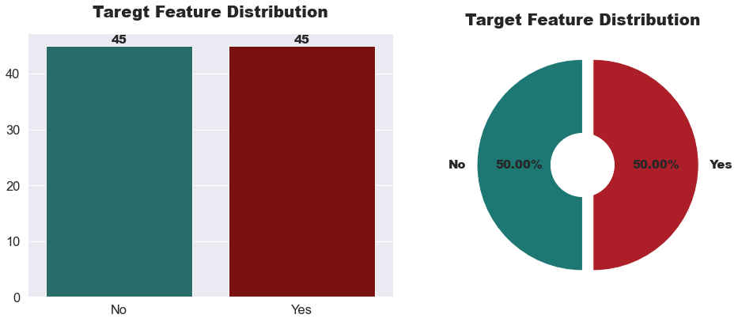

```python
plt.figure(figsize=(14,6))
plt.subplot(1,2,1)
ax=sns.barplot(y=df["Target"].value_counts().values,x=["No","Yes"],palette=["#1d7874","#8B0000"])
plt.title("Taregt Feature Distribution",fontweight="black",size=20,pad=20)
ax.bar_label(ax.containers[0],fontweight="black",size=15)



plt.subplot(1,2,2)
plt.pie(df["Target"].value_counts().values, labels=["No","Yes"], autopct="%.2f%%",
        textprops={"fontweight":"black","size":15}, colors = ["#1d7874","#AC1F29"],explode=[0,0.1],startangle=90)
center_circle = plt.Circle((0, 0), 0.3, fc='white')
fig = plt.gcf()
fig.gca().add_artist(center_circle)
plt.title("Target Feature Distribution",fontweight="black",size=20,pad=10)
plt.tight_layout()
plt.show()
```

</div>

### 📊 Inference:

- The **class is highly balanced**, which indicates that we have **equal records of patinets** who have stones in their kidney and vice-versa.
- So we **don't** have to **use** any technique like **SMOTE.**

## 2. Visualizing Urnine_Gravity Feature Distribution & Relation.

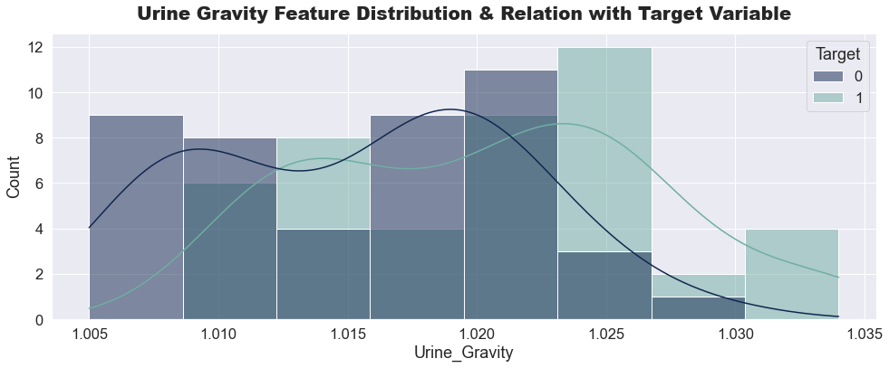

```python
plt.figure(figsize=(14,6))
sns.histplot(x=df["Urine_Gravity"],hue=df["Target"],kde=True,palette=["#11264e","#6faea4"])
plt.title("Urine Gravity Feature Distribution & Relation with Target Variable",fontweight="black",size=20,pad=15)
plt.tight_layout()
plt.show()
```

</div>

### 📊 Inference:

- **Most of patient having stone in their kidney** are having high **Urine gravity** and vice-versa.
- So we can make an infernece that **with increase in Urine gravity value** their is **more likey to have stone in their kidney.**
- Hence, this **feature is essential for model-building.**

## 3. Visualizing Urine_pH Feature Distribution & Relation.

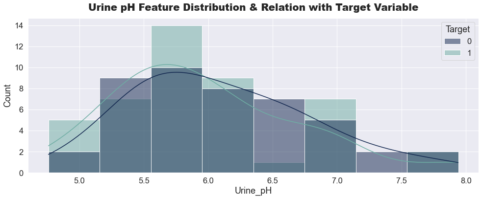

```python
plt.figure(figsize=(14,6))
sns.histplot(x=df["Urine_pH"],hue=df["Target"],kde=True,palette=["#11264e","#6faea4"])
plt.title("Urine pH Feature Distribution & Relation with Target Variable",fontweight="black",size=20,pad=15)
plt.tight_layout()
plt.show()
```

</div>

### 📊 Inference:

- **Most of patient having stone in their kidney** are likely to have **pH value very low or equal to average pH value.**
- **Some of patient having high pH values** are also **suffereing from this disease.**
- So we **can't conclude any direct relation between pH and Target Variabels.**

## 4. Visualizing Osmolality Feature Distribution & Relation.

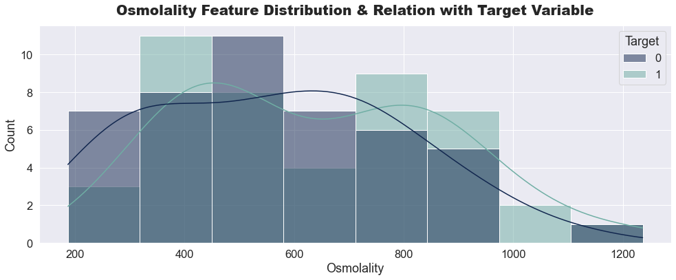

```python
plt.figure(figsize=(14,6))
sns.histplot(x=df["Osmolality"],hue=df["Target"],kde=True,palette=["#11264e","#6faea4"])
plt.title("Osmolality Feature Distribution & Relation with Target Variable",fontweight="black",size=20,pad=15)
plt.tight_layout()
plt.show()
```

</div>

## 5. Visualizing Conductivity Feature Distribution & Relation.

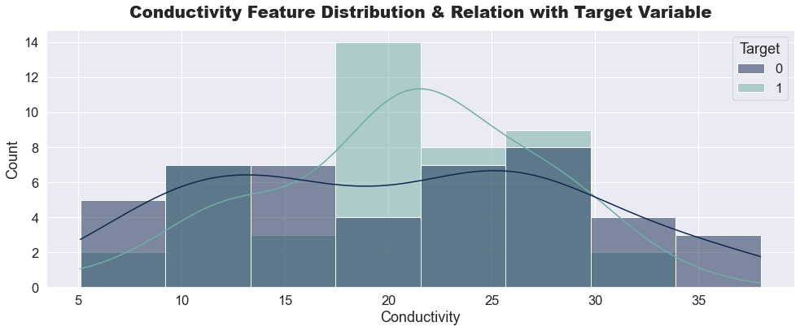

```python
plt.figure(figsize=(14,6))
sns.histplot(x=df["Conductivity"],hue=df["Target"],kde=True,palette=["#11264e","#6faea4"])
plt.title("Conductivity Feature Distribution & Relation with Target Variable",fontweight="black",size=20,pad=15)
plt.tight_layout()
plt.show()
```

</div>

### 📊 Inference:

- **Most of the patient having stone in their kidney** are having **an avergae conductivity (ion level) value.**
- But some **patient having low ion level are also suffering from this disease.**
- So we **can't conclude that there is any kind of direct relation between conductivity and target features.**

## 6. Visualizing Urea Feature Distribution & Relation.

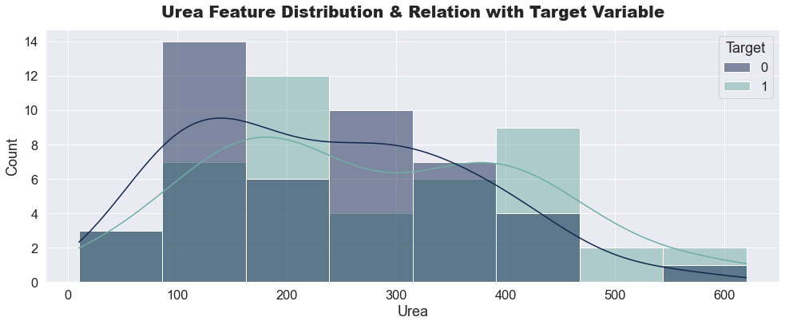

```python
plt.figure(figsize=(14,6))
sns.histplot(x=df["Urea"],hue=df["Target"],kde=True,palette=["#11264e","#6faea4"])
plt.title("Urea Feature Distribution & Relation with Target Variable",fontweight="black",size=20,pad=15)
plt.tight_layout()
plt.show()
```

</div>

## 7. Visualizing Calcium Feature Distribution & Relation.

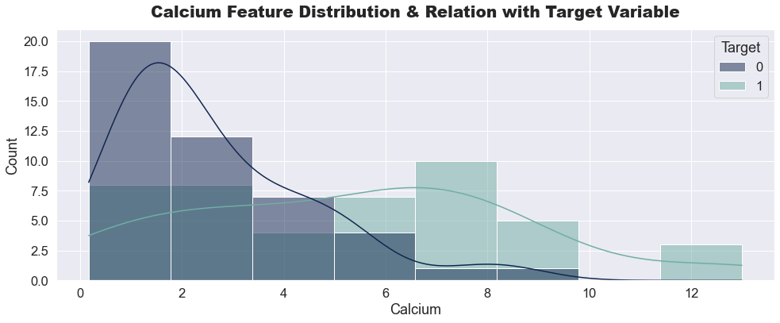

```python
plt.figure(figsize=(14,6))
sns.histplot(x=df["Calcium"],hue=df["Target"],kde=True,palette=["#11264e","#6faea4"])
plt.title("Calcium Feature Distribution & Relation with Target Variable",fontweight="black",size=20,pad=15)
plt.tight_layout()
plt.show()
```

</div>

### 📊 Inference:

- **Most of the patient having stone in their kidney** are having **high calcium values.**
- so we can make an infernece that **with increase in calcium level** there is **more chance of patinet having stone in kidney.**
- Hence, this **feature is essential for model-building.**

## 8. Detecting Outliers in Independent variables.

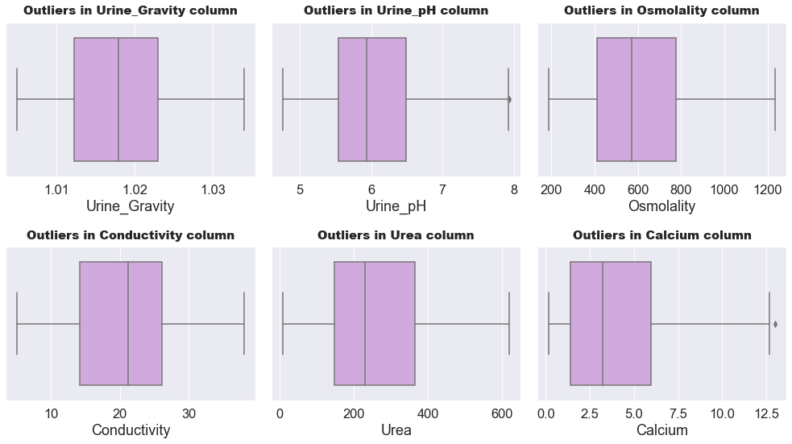

```python
ind_cols = df.columns.tolist()
ind_cols.remove("Target")

plt.figure(figsize=(14,8))
for index,column in enumerate(ind_cols):
    plt.subplot(2,3,index+1)
    sns.boxplot(df[column],palette=["#D4A1E7"])
    plt.title(f"Outliers in {column} column",fontweight="black",size=15,pad=10)
    plt.tight_layout()
```

</div>

### 📊 Inference:

- **Urine_pH** & **Calcium** features are having **have some outlier values.**
- All the features are having **stable spread** becuase they **don't have any extemly high or extremely low values**

## 9. Finidng Realtion between "Urine_Gravity w.r.t Other Features.

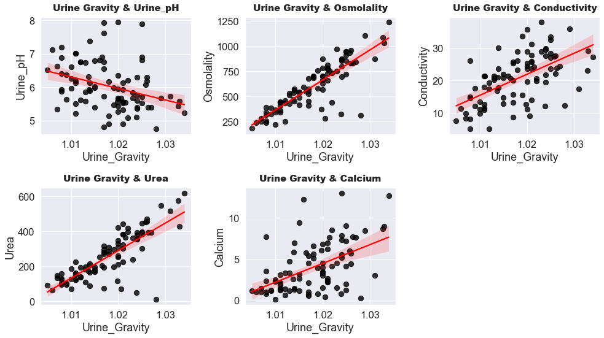

```python
cols = df.columns.tolist()
cols.remove("Urine_Gravity")
cols.remove("Target")


plt.figure(figsize=(14,8))
for index,col in enumerate(cols):
    plt.subplot(2,3,index+1)
    sns.regplot(x="Urine_Gravity",y=col,data=df,scatter_kws={'s': 70,"color":"black"}, line_kws={'color': 'red'})
    plt.title(f"Urine Gravity & {col}",fontweight="black",pad=10,size=15)
    plt.tight_layout()
```

</div>

### 📊 Inference:

- **Urea** & **Osmolality** feature are having **proper linear relation** with **Urine Gravity Feature.**
- With **increase in Urine Gravity the Urine PH decreases** so there's also a **linear relation among them.**
- Features like **Conductivity** & **Calcium** are showing **linear relation** among the features.
- So we can **conclude that Urine Gravity is an important feature which will help model in building patterns for better prediction.**

## 10. Finidng Realtion between Urine_PH w.r.t Other Features.

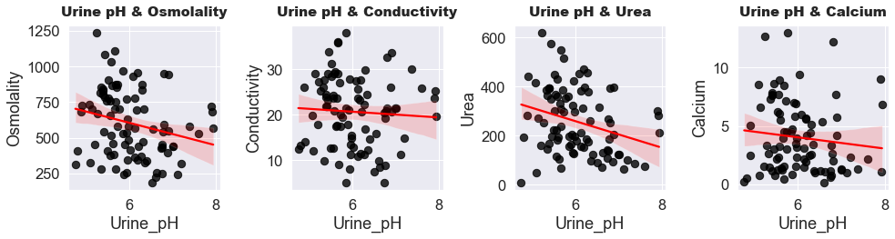

```python
cols=["Osmolality","Conductivity","Urea","Calcium"]

plt.figure(figsize=(14,4))
for index,col in enumerate(cols):
    plt.subplot(1,4,index+1)
    sns.regplot(x="Urine_pH",y=col,data=df,scatter_kws={'s': 70,"color":"black"}, line_kws={'color': 'red'})
    plt.title(f"Urine pH & {col}",fontweight="black",pad=10,size=15)
    plt.tight_layout()
```

</div>

### 📊 Inference:

- **Urine pH** feature is having **litte relation with feature Osmolality & Urea.**
- **Urine pH** is having **no relation** with **Conductivity** or **Calcium** features.**
- So **pH feature doesn't seem that much relevant for model-building.**
- Hence, we will perform **Feature Engineering to make it more relvant for model building.**

## 11. Finidng Realtion between Osmolality w.r.t Other Features.

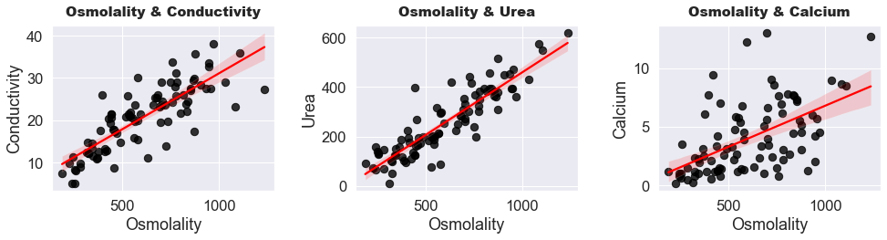

```python
cols = ["Conductivity","Urea","Calcium"]

plt.figure(figsize=(14,4))
for index,col in enumerate(cols):
    plt.subplot(1,3,index+1)
    sns.regplot(x="Osmolality",y=col,data=df,scatter_kws={'s': 70,"color":"black"}, line_kws={'color': 'red'})
    plt.title(f"Osmolality & {col}",fontweight="black",pad=10,size=15)
    plt.tight_layout()
```

</div>

### 📊 Inference:

- **Osmolality** feature is having **strong linear relation** with **Conductivity, Urea, Calcium** features.
- So we can **conclude that Osmolality is an important feature which will help model in building patterns for better prediction.**

## 12. Finidng Realtion between Conductivity w.r.t Other Features.

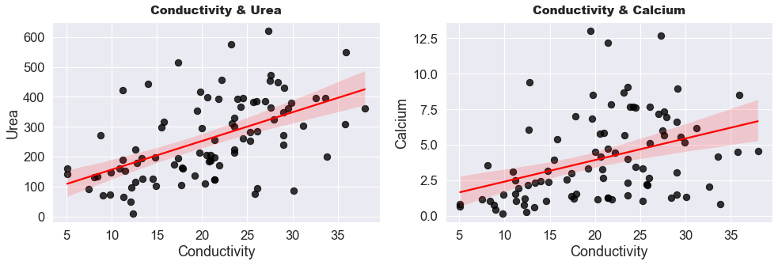

```python
cols = ["Urea","Calcium"]

plt.figure(figsize=(14,5))
for index,col in enumerate(cols):
    plt.subplot(1,2,index+1)
    sns.regplot(x="Conductivity",y=col,data=df,scatter_kws={'s': 70,"color":"black"}, line_kws={'color': 'red'})
    plt.title(f"Conductivity & {col}",fontweight="black",pad=10,size=15)
    plt.tight_layout()
```

</div>

### 📊 Inference:

- **Conductivity** feature is having **little linear relation** with **Urea, Calcium** features.
- So we can **conclude that conductivity is an important feature which will help model in building patterns for better prediction.**

## 13. Finidng Realtion between Urea & Calcium Features.

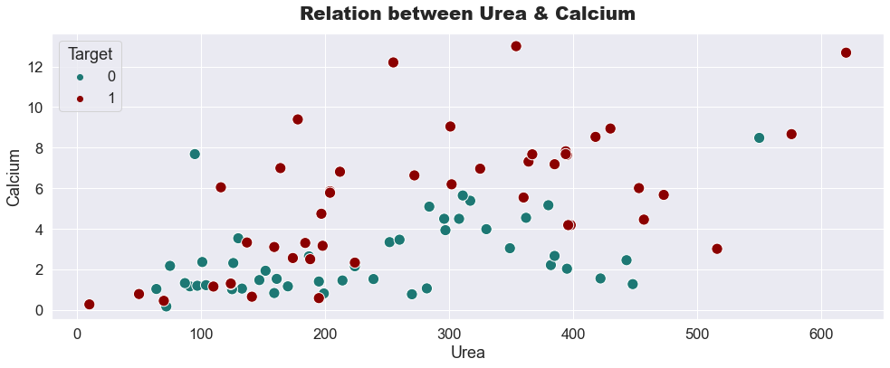

```python
plt.figure(figsize=(14,6))
sns.scatterplot(x="Urea",y="Calcium",data=df,hue="Target", markers=["o", "s"], s=150,palette=["#1d7874","#8B0000"])
plt.title("Relation between Urea & Calcium",fontweight="black",size=20,pad=15)
plt.tight_layout()
plt.show()
```

</div>

### 📊 Inference:

- We can clearly observe that **with increase in Urea, Calcium also increases**.
- Patients having **high calcium values** are **more likey to have stone in their kidney.**
- So we can **conclude that Calcium & Urea is an important feature which will help model in building patterns for better prediction.**

# **💡 Feature Engineering 💡**

### 1. Creating New Feature by using Urine_pH Column.

```python
df[["Urine_pH"]].describe().T
```

|  | count | mean | std | min | 25% | 50% | 75% | max |
| --- | --- | --- | --- | --- | --- | --- | --- | --- |
| Urine_pH | 90.0 | 6.036651 | 0.711801 | 4.76 | 5.53652 | 5.936247 | 6.49 | 7.94 |

</div>

### 📊 Note:

- From **above eda** we concluded that **Urine_pH** feature is **not that relevant** for **model-building.**
- So we can create a **new feature by creating bins to show Urine_pH scale**, **`Acidic`**, **`Neutral`**, **`Alkaline`**.

### 2. Create Bins using Urine Urine_pH column.

```python
bin_edges = [4.70, 5.53652, 6.49, 7.94]
bin_labels = ['Acidic', 'Neutral', 'Alkaline']


df['Urine_pH_bin'] = pd.cut(df['Urine_pH'], bins=bin_edges, labels=bin_labels)
```

```python
df["Urine_pH_bin"].sample(5).to_frame()
```

|  | Urine_pH_bin |
| --- | --- |
| 70 | Acidic |
| 23 | Neutral |
| 56 | Alkaline |
| 75 | Alkaline |
| 74 | Acidic |

### 3. Visualizing New Feature Urine_pH_bin w.r.t Target Variable.

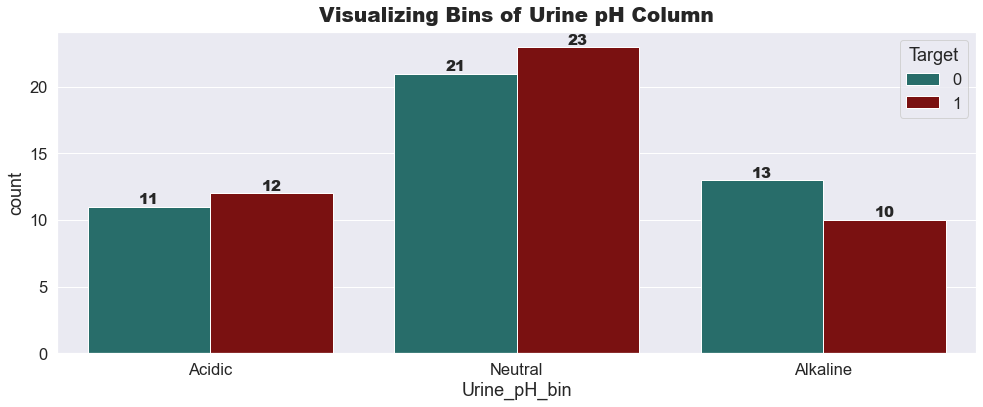

```python
plt.figure(figsize=(14,6))
ax=sns.countplot(df["Urine_pH_bin"],hue=df["Target"],palette=["#1d7874","#8B0000"])
ax.bar_label(ax.containers[0],fontweight="black",size=15)
ax.bar_label(ax.containers[1],fontweight="black",size=15)
plt.title("Visualizing Bins of Urine pH Column",fontweight="black",size=20,pad=10)
plt.tight_layout()
plt.show()
```

</div>

### 📊 Inference:

- Both the **categories of target variable** are having **approxiamately equal patients**
- So from this new feature we can conclude that **Patinet having stone in their kidney may or may not depend on Urine_pH.**

# **📈 Statistical Analysis - Feature Importance.📈**

</div>

### 📊 Note:

- **Null Hyothesis:** There is **no relation** among the feature.
- **ALternate Hypothesis:** There is **relation** among the feature.

## 1. Performing ANOVA Test to Analyze the Numerical Features Importance in Kidney Stone.

```python
num_cols = df.select_dtypes(np.number).columns.tolist()

f_scores = {}
p_values = {}

for column in num_cols:
    f_score, p_value = stats.f_oneway(df["Target"],df[column])
    f_scores[column] = f_score
    p_values[column] = p_value
```

## 2. Comparing F_Score and P_value of ANOVA Test.

```python
test_df = pd.DataFrame({"Features":f_scores.keys(),"F_Score":f_scores.values()})
test_df["P_value"] = p_values.values()
test_df
```

|  | Features | F_Score | P_value |
| --- | --- | --- | --- |
| 0 | Urine_Gravity | 95.488215 | 2.512290e-18 |
| 1 | Urine_pH | 3632.673094 | 2.315363e-120 |
| 2 | Osmolality | 573.274581 | 1.497575e-57 |
| 3 | Conductivity | 619.260888 | 7.502950e-60 |
| 4 | Urea | 326.098731 | 4.294252e-42 |
| 5 | Calcium | 119.106962 | 1.476426e-21 |
| 6 | Target | 0.000000 | 1.000000e+00 |

</div>

### 📊 Inference:

- Based on the **P-Values following conclusion can be made.**
  - **`Urine_Gravity: p-value < 0.05 (Reject null hypothesis)`**
  - **`Urine_pH: p-value < 0.05 (Reject null hypothesis)`**
  - **`Osmolality: p-value < 0.05 (Reject null hypothesis)`**
  - **`Conductivity: p-value < 0.05 (Reject null hypothesis)`**
  - **`Urea: p-value < 0.05 (Reject null hypothesis)`**
  - **`Calcium: p-value < 0.05 (Reject null hypothesis)`**
- Since we have to **reject null hypothesis** for each colum.
- Hence, we can conclude that all the **features have relation with the target variable.**

## 3. Performing Chi-Square Test to identify the relation bwteen Target & Urine_pH_bin feature.

```python
contingency_table = pd.crosstab(df["Target"], df['Urine_pH_bin'])

chi2, p_value, _, _ = stats.chi2_contingency(contingency_table)

print("P-Value is:",p_value)
```

```
P-Value is: 0.7688604081605568
```

</div>

### 📊 Inference:

- Since the **p-value is > 0.05** so we were **failed to reject the null hypothesis.**
- Hencce we can conclude that there is **no relation between those two features.**
- So the **new feature we created doesn't seem to be relevant with target feature.**

# **⚙️ Data Preprocessing ⚙️**

### 1. Dropping Features which are not Relevant.

```python
df.drop(columns=["Urine_pH_bin"],inplace=True)
```

### 2. Segregating Features & Labels for Model Training.

```python
X = df.drop(columns=["Target"])
y = df["Target"]
```

### 3. Splitting Data For Model Training & Testing.

```python
x_train,x_test,y_train,y_test = train_test_split(X,y,test_size=0.2,random_state=0)
```

```python
print("Shape of x_train is:",x_train.shape)
print("Shape of x_test is: ",x_test.shape)
print("Shape of y_train is:",y_train.shape)
print("Shape of y_test is: ",y_test.shape)
```

```
Shape of x_train is: (72, 6)
Shape of x_test is:  (18, 6)
Shape of y_train is: (72,)
Shape of y_test is:  (18,)
```

### 📊 Inference:

# **🎯 Model Creation using DecisionTree 🎯**

### 1. Performing Grid-Search with cross-validation to find the best Parameters for the Model.

```python
dtree = DecisionTreeClassifier()
```

```python
param_grid = {"max_depth":[3,4,5,6,7,8,9,10],
              "min_samples_split":[2,3,4,5,6,7,8],
              "min_samples_leaf":[1,2,3,4,5,6,7,8],
              "criterion":["gini","entropy"],
              "splitter":["best","random"],
              "max_features":["auto",None],
              "random_state":[0,42]}
```

```python
grid_search = GridSearchCV(dtree, param_grid, cv=5, n_jobs=-1)

grid_search.fit(x_train,y_train)
```

```
GridSearchCV(cv=5, estimator=DecisionTreeClassifier(), n_jobs=-1,
             param_grid={'criterion': ['gini', 'entropy'],
                         'max_depth': [3, 4, 5, 6, 7, 8, 9, 10],
                         'max_features': ['auto', None],
                         'min_samples_leaf': [1, 2, 3, 4, 5, 6, 7, 8],
                         'min_samples_split': [2, 3, 4, 5, 6, 7, 8],
                         'random_state': [0, 42],
                         'splitter': ['best', 'random']})
```

### 2. Fetching the Best Parameters for DecisionTree Model.

```python
best_parameters = grid_search.best_params_

print("Best Parameters for DecisionTree Model is:\n\n")
best_parameters
```

```
Best Parameters for DecisionTree Model is:
```

```
{'criterion': 'gini',
 'max_depth': 8,
 'max_features': None,
 'min_samples_leaf': 1,
 'min_samples_split': 2,
 'random_state': 0,
 'splitter': 'random'}
```

### 3. Creating DecisionTree Model Using Best Parameters.

```python
dtree = DecisionTreeClassifier(**best_parameters)

dtree.fit(x_train,y_train)
```

```
DecisionTreeClassifier(max_depth=8, random_state=0, splitter='random')
```

### 4. Computing Model Accuracy.

```python
y_train_pred = dtree.predict(x_train)
y_test_pred = dtree.predict(x_test)

print("Accuracy Score of Model on Training Data is =>",round(accuracy_score(y_train,y_train_pred)*100,2),"%")
print("Accuracy Score of Model on Testing Data  is =>",round(accuracy_score(y_test,y_test_pred)*100,2),"%")
```

```
Accuracy Score of Model on Training Data is => 97.22 %
Accuracy Score of Model on Testing Data  is => 83.33 %
```

### 5. Model Evaluation using Different Metric Values.

```python
print("F1 Score of the Model is =>",f1_score(y_test,y_test_pred))
print("Recall Score of the Model is =>",recall_score(y_test,y_test_pred))
print("Precision Score of the Model is =>",precision_score(y_test,y_test_pred))
```

```
F1 Score of the Model is => 0.7999999999999999
Recall Score of the Model is => 0.8571428571428571
Precision Score of the Model is => 0.75
```

### 📊 Inference:

- Training accuracy is **97%** where as testing accuracy is **83%**. So we can say the model is overfit even after hyper-parameter tunning.
- We can observe that **recall, precision, and F1 score are near to 0.8**, it means that our **model is achievinga balanced fit between** correctly identifying **positive samples (recall)** and minimizing **false positives (precision).**

### 6. Finding Importance of Features in DecisionTreeClassifier.

```python
imp_df = pd.DataFrame({"Feature Name":x_train.columns,
                       "Importance":dtree.feature_importances_})
```

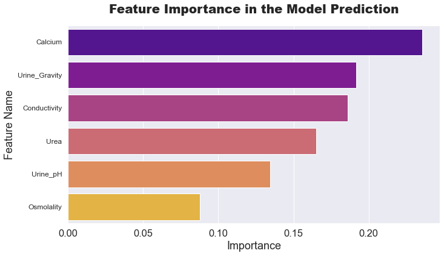

```python
features = imp_df.sort_values(by="Importance",ascending=False)

plt.figure(figsize=(11,6))
sns.barplot(x="Importance", y="Feature Name", data=features, palette="plasma")
plt.title("Feature Importance in the Model Prediction", fontweight="black", size=20, pad=20)
plt.yticks(size=12)
plt.show()
```

### 📊 Inference:

- The **key factors** that significantly influence the **Kidney Stone patient are:** are:-
  - **`Clacium`**, **`Urine_Gravity`**, and **`Conductivity`**.
- The **minimal impact** of features on the **kidney stone patient are:** are:-
  - **`Osmolality`**, and **`Urine_pH`**

### 7. SHAP Summary Plot: Explaining Model Predictions with Feature Importance.

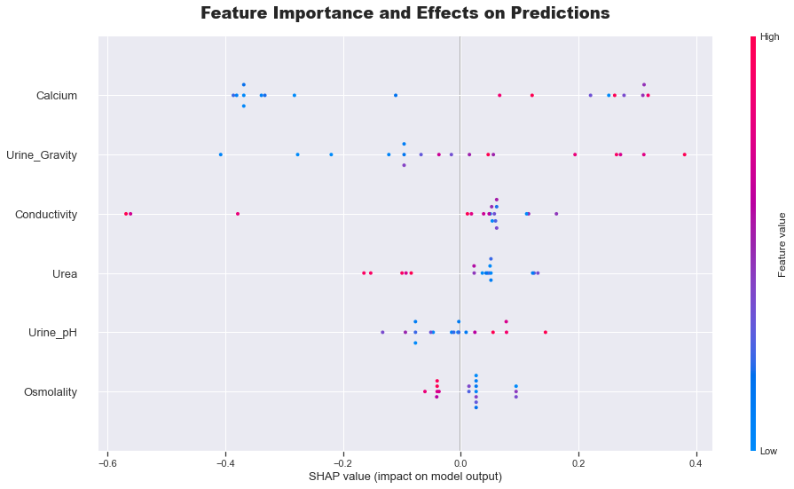

```python
import shap
explainer = shap.TreeExplainer(dtree)
shap_values = explainer.shap_values(x_test)

plt.title("Feature Importance and Effects on Predictions",fontweight="black",pad=20,size=18)
shap.summary_plot(shap_values[1], x_test.values, feature_names = x_test.columns,plot_size=(14,8))
```

### 8. Model Evaluation using Confusion Matrix.

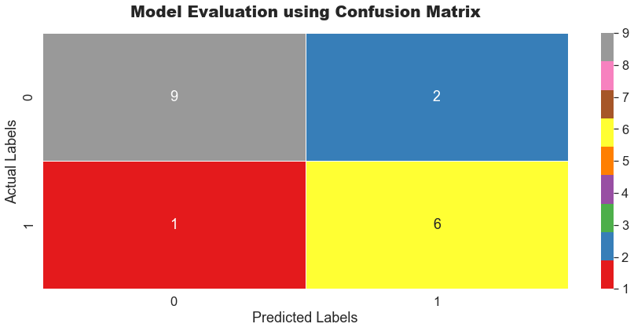

```python
cm = confusion_matrix(y_test,y_test_pred)

plt.figure(figsize=(15,6))
sns.heatmap(data=cm, linewidth=.5, annot=True, fmt="g", cmap="Set1")
plt.title("Model Evaluation using Confusion Matrix",fontsize=20,pad=20,fontweight="black")
plt.ylabel("Actual Labels")
plt.xlabel("Predicted Labels")
plt.show()
```

### 9. Model Evaluation: ROC Curve and Area Under the Curve (AUC)

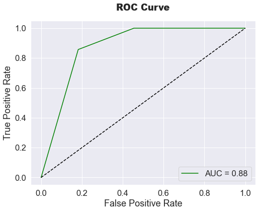

```python
y_pred_proba = dtree.predict_proba(x_test)[:][:,1]

df_actual_predicted = pd.concat([pd.DataFrame(np.array(y_test), columns=["y_actual"])])
df_actual_predicted.index = y_test.index


fpr, tpr, thresholds = roc_curve(df_actual_predicted["y_actual"], y_pred_proba)
auc = roc_auc_score(df_actual_predicted["y_actual"], y_pred_proba)

plt.figure(figsize=(8, 6))
plt.plot(fpr, tpr, label=f"AUC = {auc:.2f}",color="green")
plt.plot([0, 1], [0, 1], linestyle="--", color="black")
plt.xlabel("False Positive Rate")
plt.ylabel("True Positive Rate")
plt.title("ROC Curve",pad=20,fontweight="black")
plt.legend()
plt.show()
```

### 📊 Inference:

1. An **AUC (Area Under the Curve) value of 0.88** suggests that the model has **strong discriminative power.**
2. This suggests that the model has a **high ability to distinguish between positive and negative instances**, indicating its effectiveness in making accurate predictions.

# **🎯 Model Creation using RandomForest 🎯**

### 1. Performing Grid-Search with cross-validation to find the best Parameters for the Model.

```python
rfc = RandomForestClassifier()
```

```python
param_grid = {"max_depth":[3,4,5,6,7,8],
              "min_samples_split":[3,4,5,6,7,8],
              "min_samples_leaf":[3,4,5,6,7,8],
              "n_estimators": [50,70,90,100],
              "criterion":["gini","entropy"]}
```

```python
grid_search = GridSearchCV(rfc, param_grid, cv=5, n_jobs=-1)

grid_search.fit(x_train,y_train)
```

```
GridSearchCV(cv=5, estimator=RandomForestClassifier(), n_jobs=-1,
             param_grid={'criterion': ['gini', 'entropy'],
                         'max_depth': [3, 4, 5, 6, 7, 8],
                         'min_samples_leaf': [3, 4, 5, 6, 7, 8],
                         'min_samples_split': [3, 4, 5, 6, 7, 8],
                         'n_estimators': [50, 70, 90, 100]})
```

### 2. Fetching the Best Parameters for RandomForest Model.

```python
best_parameters = grid_search.best_params_

print("Best Parameters for RandomForest Model is:\n\n")
best_parameters
```

```
Best Parameters for RandomForest Model is:
```

```
{'criterion': 'entropy',
 'max_depth': 7,
 'min_samples_leaf': 3,
 'min_samples_split': 6,
 'n_estimators': 50}
```

### 3. Creating RandomForest Model Using Best Parameters.

```python
rfc = RandomForestClassifier(**best_parameters)

rfc.fit(x_train,y_train)
```

```
RandomForestClassifier(criterion='entropy', max_depth=7, min_samples_leaf=3,
                       min_samples_split=6, n_estimators=50)
```

### 4. Computing Model Accuracy.

```python
y_train_pred = rfc.predict(x_train)
y_test_pred  = rfc.predict(x_test)

print("Accuracy Score of Model on Training Data is =>",round(accuracy_score(y_train,y_train_pred)*100,2),"%")
print("Accuracy Score of Model on Testing Data  is =>",round(accuracy_score(y_test,y_test_pred)*100,2),"%")
```

```
Accuracy Score of Model on Training Data is => 95.83 %
Accuracy Score of Model on Testing Data  is => 88.89 %
```

### 5. Model Evaluation using Different Metric Values.

```python
print("F1 Score of the Model is =>",f1_score(y_test,y_test_pred))
print("Recall Score of the Model is =>",recall_score(y_test,y_test_pred))
print("Precision Score of the Model is =>",precision_score(y_test,y_test_pred))
```

```
F1 Score of the Model is => 0.8571428571428571
Recall Score of the Model is => 0.8571428571428571
Precision Score of the Model is => 0.8571428571428571
```

### 📊 Inference:

- Model **accuracy** on traiining data is **95%** and on the testing data is **88%**. So the model is having a kind of **best fit.**
- We can observe that **recall, precision, and F1 score are all the same**, it means that our **model is achieving perfect balance between** correctly identifying **positive samples (recall)** and minimizing **false positives (precision).**

### 6. Finding Importance of Features in RandomForest Model.

```python
imp_df = pd.DataFrame({"Feature Name":x_train.columns,
                       "Importance":rfc.feature_importances_})
```

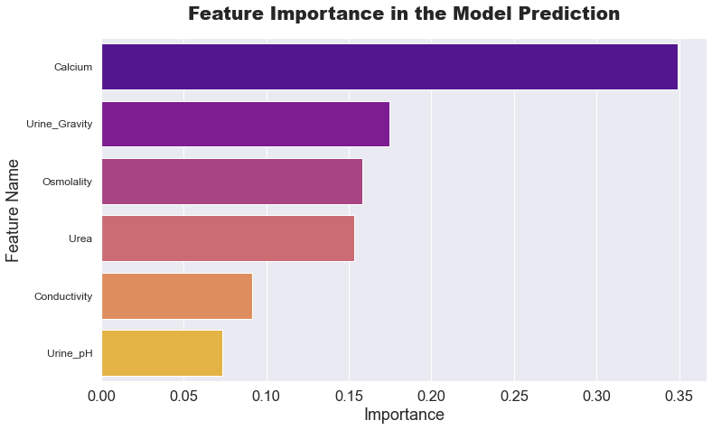

```python
features = imp_df.sort_values(by="Importance",ascending=False)

plt.figure(figsize=(12,7))
sns.barplot(x="Importance", y="Feature Name", data=features, palette="plasma")
plt.title("Feature Importance in the Model Prediction", fontweight="black", size=20, pad=20)
plt.yticks(size=12)
plt.show()
```

### 📊 Inference:

- The **key factors** that significantly influence the **kidney stone patient** are:-
  - **`Calcium`**, **`Urine_Gravity`**, and **`Osmolality`**.
- The **minimal impact** of features on the **kidney stone patient** are:-
  - **`Urine pH`** and **`Conductivity`**.

### 7. SHAP Summary Plot: Explaining Model Predictions with Feature Importance.

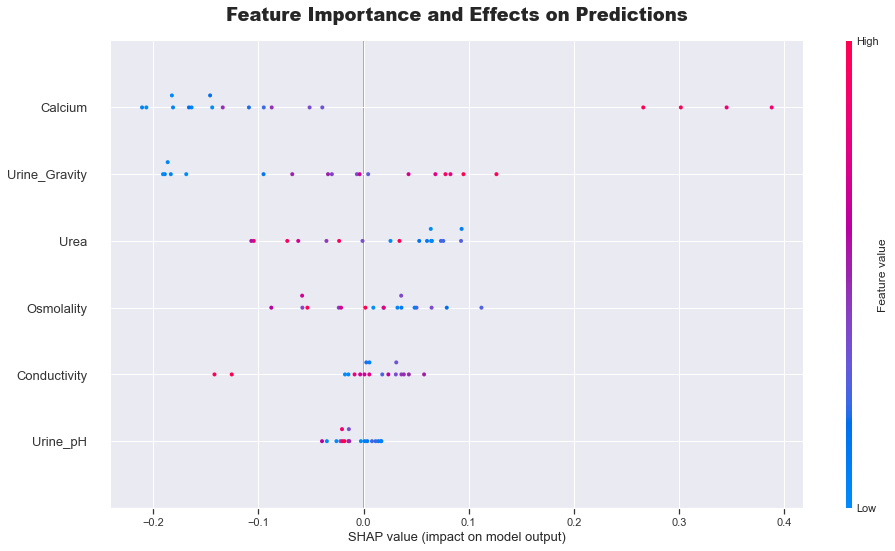

```python
import shap
explainer = shap.TreeExplainer(rfc)
shap_values = explainer.shap_values(x_test)

plt.title("Feature Importance and Effects on Predictions",fontweight="black",pad=20,size=18)
shap.summary_plot(shap_values[1], x_test.values, feature_names = x_test.columns,plot_size=(14,8))
```

### 8. Model Evaluation using Confusion Matrix.

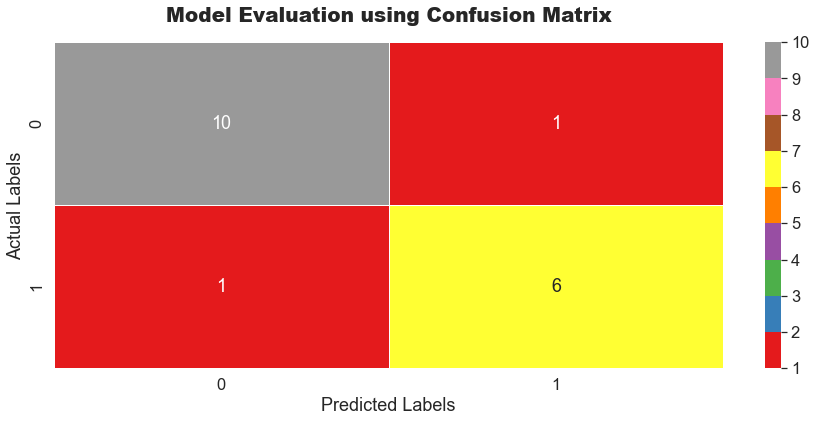

```python
cm = confusion_matrix(y_test,y_test_pred)

plt.figure(figsize=(15,6))
sns.heatmap(data=cm, linewidth=.5, annot=True, fmt="g", cmap="Set1")
plt.title("Model Evaluation using Confusion Matrix",fontsize=20,pad=20,fontweight="black")
plt.ylabel("Actual Labels")
plt.xlabel("Predicted Labels")
plt.show()
```

### 9. Model Evaluation: ROC Curve and Area Under the Curve (AUC)

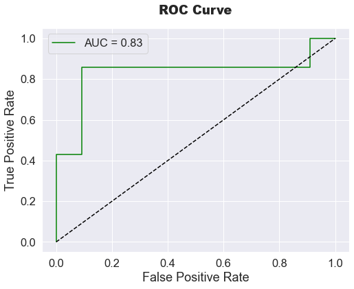

```python
y_pred_proba = rfc.predict_proba(x_test)[:][:,1]

df_actual_predicted = pd.concat([pd.DataFrame(np.array(y_test), columns=["y_actual"])])
df_actual_predicted.index = y_test.index


fpr, tpr, thresholds = roc_curve(df_actual_predicted["y_actual"], y_pred_proba)
auc = roc_auc_score(df_actual_predicted["y_actual"], y_pred_proba)

plt.figure(figsize=(8, 6))
plt.plot(fpr, tpr, label=f"AUC = {auc:.2f}",color="green")
plt.plot([0, 1], [0, 1], linestyle="--", color="black")
plt.xlabel("False Positive Rate")
plt.ylabel("True Positive Rate")
plt.title("ROC Curve",pad=20,fontweight="black")
plt.legend()
plt.show()
```

### 📊 Inference:

1. An **AUC (Area Under the Curve) value of 0.83** suggests that the model has **strong discriminative power.**
2. This suggests that the model has a **high ability to distinguish between positive and negative instances**, indicating its effectiveness in making accurate predictions.

# **🎈 Conclusion 🎈**

### 📊 Inference:

- The **model demonstrates strong performance** with an accuracy of **95% on training data and 88% on testing data**, indicating a solid fit to the dataset.
- Remarkably, the **model achieves consistent recall, precision, and F1 score values**, suggesting a perfect balance between effectively identifying positive cases and minimizing false positives.
- The pivotal **factors significantly impacting kidney stone patients** are identified as **`Calcium`**, **`Urine_Gravity`**, and **`Osmolality`**, underscoring their vital roles in predicting the presence of kidney stones.
- Conversely, **`Urine pH`** and **`Conductivity`** are found to have **minimal impact on distinguishing kidney stone patients**, suggesting these features may be less influential in the predictive process.
- **Overall, the model's accuracy, balanced metrics, and key feature insights collectively contribute to a comprehensive understanding of kidney stone prediction**, potentially aiding in early detection and better patient care.